# Practical Machine Learning Assignment

## Introduction to the project

One thing that people regularly do is quantify how much of a particular activity they do, but they rarely quantify how well they do it. In this project, we will use data from accelerometers on the belt, forearm, arm, and dumbell of 6 participants.The goal of your project is to predict the manner in which they did the exercise.

## Data Sources

The training Datset set is available at:  
[Training Dataset](https://d396qusza40orc.cloudfront.net/predmachlearn/pml-training.csv)

The testing Dataset is available at:  
[Testing Dataset](https://d396qusza40orc.cloudfront.net/predmachlearn/pml-testing.csv)

# Data Exploration

```r
library(caret)
```

```r
library(ggplot2)
library(rattle)
library(randomForest)
```

Reading the training and testing Dataset:

```r
training<-read.csv("training.csv")[,c(-1)]#as they are just row numbers
testing<-read.csv("testing.csv")[,c(-1)]# as they are just row numbers
dim(training)
```

```
## [1] 19622   159
```

```r
dim(testing)
```

```
## [1]  20 159
```

As it can be seen that the data is multidimensional and hence the columns with approximately zero variance should be removed.Approaches such as Principal component analysis could also be used.  
Rows with NA values should also be removed.

## Data preprocessing

```r
nzv<-nearZeroVar(training)
#this variable contains the columns with almost zero variance
training<-training[,-nzv]
testing<-testing[,-nzv]
dim(training)
```

```
## [1] 19622    99
```

```r
dim(testing)
```

```
## [1] 20 99
```

Now removing the variables with more than 60% NA values,as they wont be much impactful for prediction model.

```r
NaValues<-sapply(training ,function(x) mean(is.na(x))>0.6)
training<-training[,NaValues==FALSE]
testing<-testing[,NaValues==FALSE]
# removing the id and time variables as they wont effect the model
training <- training[,-c(1:5)]
testing <- testing[,-c(1:5)]

dim(training)
```

```
## [1] 19622    53
```

```r
dim(testing)
```

```
## [1] 20 53
```

## Training Models

Creating validation dataset:

```r
ind<-createDataPartition(training$classe,p=0.75,list=FALSE)
training<-training[ind,]
validation<-training[-ind,]
dim(training)
```

```
## [1] 14718    53
```

```r
dim(validation)
```

```
## [1] 3679   53
```

### Prediction using Decision trees

```r
model1<-train(classe~.,data=training,method="rpart",trControl=trainControl(method="cv"))
pred1<-predict(model1,validation)
confusionMatrix(factor(pred1),factor(validation$classe))
```

```
## Confusion Matrix and Statistics
##
##           Reference
## Prediction   A   B   C   D   E
##          A 939 302 284 277  81
##          B  15 238  22 103  89
##          C  89 157 344 239 179
##          D   0   0   0   0   0
##          E  10   0   0   0 313
##
## Overall Statistics
##
##                Accuracy : 0.4982
##                  95% CI : (0.482, 0.5145)
##     No Information Rate : 0.2861
##     P-Value [Acc > NIR] : < 2.2e-16
##
##                   Kappa : 0.3445
##  Mcnemar's Test P-Value : NA
##
## Statistics by Class:
##
##                      Class: A Class: B Class: C Class: D Class: E
## Sensitivity            0.8917  0.34146  0.52923   0.0000  0.47281
## Specificity            0.6408  0.92326  0.78093   1.0000  0.99669
## Pos Pred Value         0.4987  0.50964  0.34127      NaN  0.96904
## Neg Pred Value         0.9366  0.85719  0.88552   0.8318  0.89607
## Prevalence             0.2861  0.18935  0.17658   0.1682  0.17984
## Detection Rate         0.2551  0.06466  0.09345   0.0000  0.08503
## Detection Prevalence   0.5115  0.12687  0.27384   0.0000  0.08775
## Balanced Accuracy      0.7663  0.63236  0.65508   0.5000  0.73475
```

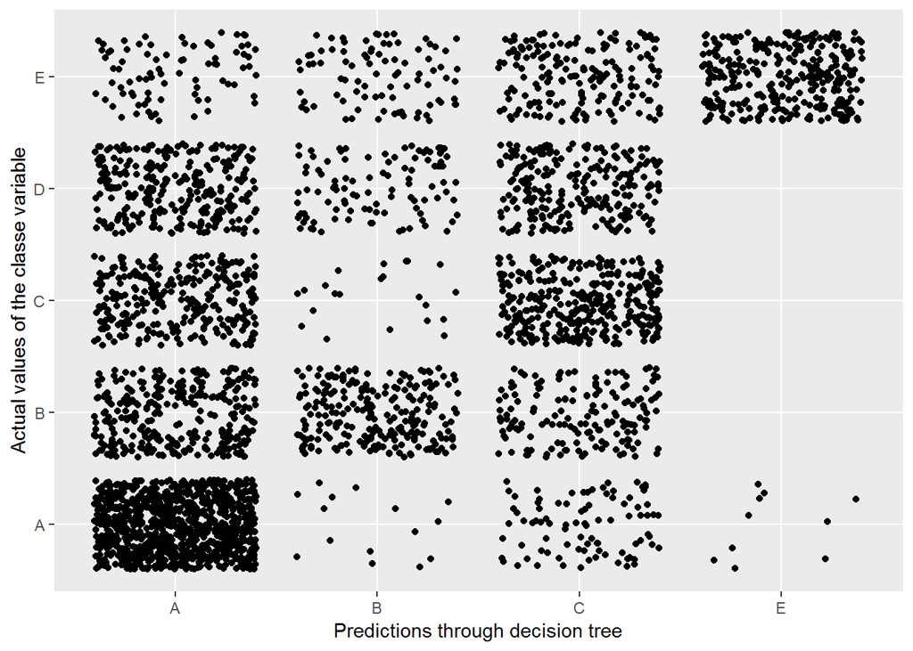

```r
qplot(pred1,validation$classe,xlab="Predictions through decision tree",ylab="Actual values of the classe variable",geom=c("jitter"))
```

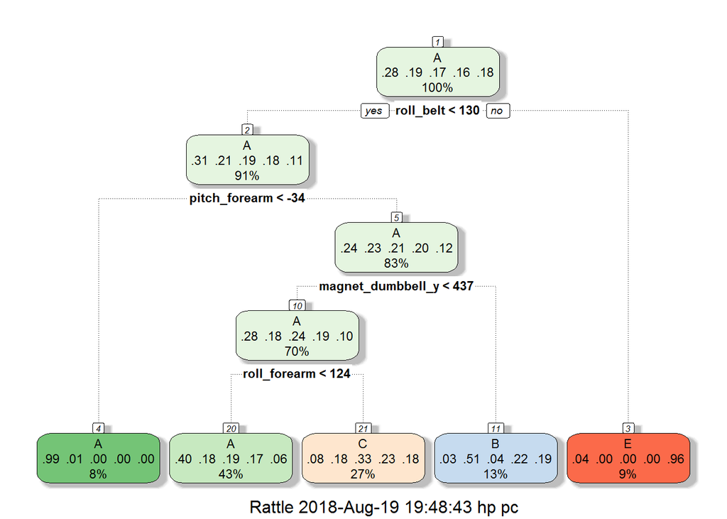

```r
fancyRpartPlot(model1$finalModel)
```

The above plot shows the decision tree used for prediction.

### Prediction using random forest

```r
model2<-randomForest(classe~.,data=training)
pred2<-predict(model2,validation)
confusionMatrix(factor(pred2),factor(validation$classe))
```

```
## Confusion Matrix and Statistics
##
##           Reference
## Prediction    A    B    C    D    E
##          A 1048    0    0    0    0
##          B    0  712    0    0    0
##          C    0    0  642    0    0
##          D    0    0    0  598    0
##          E    0    0    0    0  679
##
## Overall Statistics
##
##                Accuracy : 1
##                  95% CI : (0.999, 1)
##     No Information Rate : 0.2849
##     P-Value [Acc > NIR] : < 2.2e-16
##
##                   Kappa : 1
##  Mcnemar's Test P-Value : NA
##
## Statistics by Class:
##
##                      Class: A Class: B Class: C Class: D Class: E
## Sensitivity            1.0000   1.0000   1.0000   1.0000   1.0000
## Specificity            1.0000   1.0000   1.0000   1.0000   1.0000
## Pos Pred Value         1.0000   1.0000   1.0000   1.0000   1.0000
## Neg Pred Value         1.0000   1.0000   1.0000   1.0000   1.0000
## Prevalence             0.2849   0.1935   0.1745   0.1625   0.1846
## Detection Rate         0.2849   0.1935   0.1745   0.1625   0.1846
## Detection Prevalence   0.2849   0.1935   0.1745   0.1625   0.1846
## Balanced Accuracy      1.0000   1.0000   1.0000   1.0000   1.0000
```

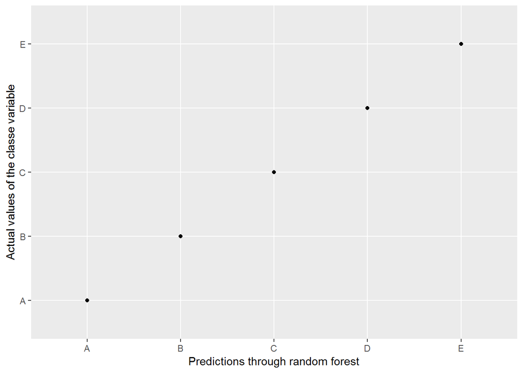

```r
qplot(pred2,validation$classe,xlab="Predictions through random forest",ylab="Actual values of the classe variable")
```

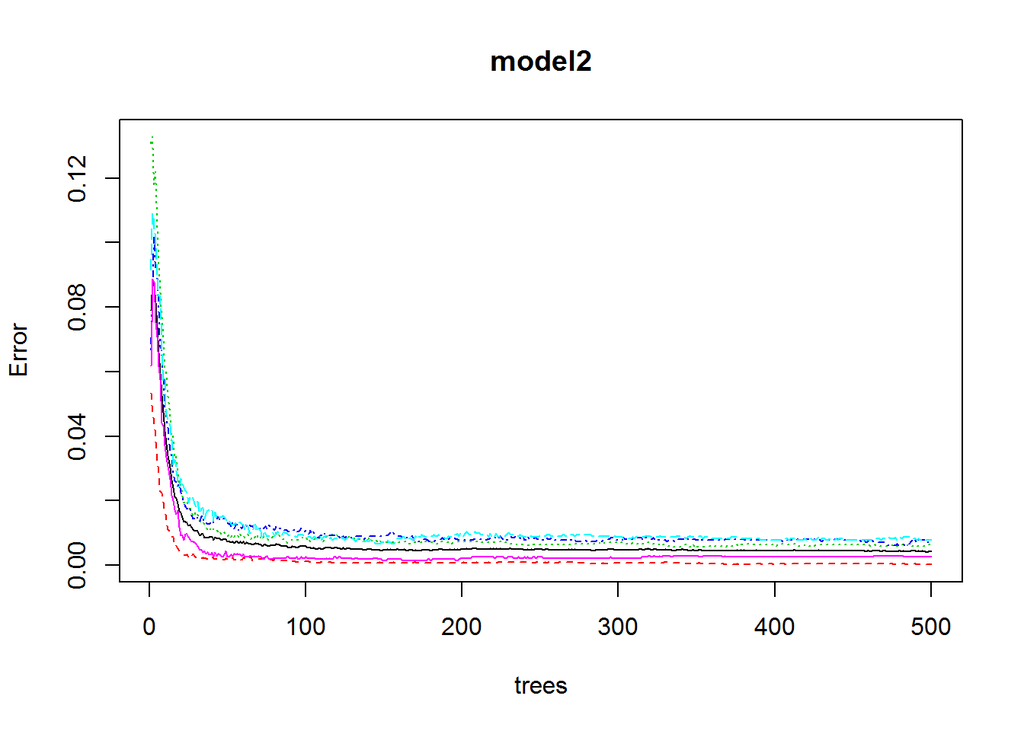

```r
plot(model2)
```

## Prediction for the test set

```r
final_pred<-predict(model2,testing)
final_pred
```

```
##  1  2  3  4  5  6  7  8  9 10 11 12 13 14 15 16 17 18 19 20
##  B  A  B  A  A  E  D  B  A  A  B  C  B  A  E  E  A  B  B  B
## Levels: A B C D E
```